# Activitat 1: Exploració i preprocés de dades

Marc Bracons Cucó

28 de marzo, 2024

# 1. Lectura de dades i examinació del tipus de variable

## 1.1 Carregar el fitxer de dades

Llegir el fitxer de dades i consultar el nom de les columnes del fitxer.

```r
# Càrrega del fitxer:
dades <- read.csv('pisa2009-1.csv')

# Consulta del nom de les columnes:
names(dades)
```

```
##  [1] "grade"                 "male"                  "raceeth"
##  [4] "preschool"             "expectBachelors"       "motherHS"
##  [7] "motherBachelors"       "motherWork"            "fatherHS"
## [10] "fatherBachelors"       "fatherWork"            "selfBornUS"
## [13] "motherBornUS"          "fatherBornUS"          "englishAtHome"
## [16] "computerForSchoolwork" "read30MinsADay"        "minutesPerWeekEnglish"
## [19] "studentsInEnglish"     "schoolHasLibrary"      "publicSchool"
## [22] "urban"                 "schoolSize"            "readingScore"
```

## 1.2 Examinar el tipus de dades

Indicar quines variables són de naturalesa numèrica, caràcter i categòrica. En cas que el tipus de variable que ha atorgat R no coincideixi amb el tipus que li correspondria, indicar de quines variables es tracta. Considereu que les variables binàries prenen valors 1 o 0. La transformació corresponent, si és necessària, s’aplicarà en els apartats següents, una vegada normalitzades les variables.

```r
# Tipus de variables:
sapply(dades, class)
```

```
##                 grade                  male               raceeth
##             "integer"             "integer"           "character"
##             preschool       expectBachelors              motherHS
##             "integer"             "integer"             "integer"
##       motherBachelors            motherWork              fatherHS
##             "integer"             "integer"             "integer"
##       fatherBachelors            fatherWork            selfBornUS
##             "integer"             "integer"             "integer"
##          motherBornUS          fatherBornUS         englishAtHome
##             "integer"             "integer"             "integer"
## computerForSchoolwork        read30MinsADay minutesPerWeekEnglish
##             "integer"           "character"             "integer"
##     studentsInEnglish      schoolHasLibrary          publicSchool
##             "integer"             "integer"             "integer"
##                 urban            schoolSize          readingScore
##             "integer"             "integer"           "character"
```

Podem veure que R ha detectat el tipus de variables com a “integer” o “character”. A continuació mostrem la agrupació feta i en discutim els resultats.

```r
# Guardar informació del tipus de variables a 'tipus_variables':
tipus_variables <- sapply(dades, class)

# Agrupar en els dos grups detectats:
int_var <- names(tipus_variables[tipus_variables == "integer"])
char_var <- names(tipus_variables[tipus_variables == "character"])

# Mostrar els resultats:
cat("Variables Integer:\n", paste(int_var, collapse = ", "), "\n")
```

```
## Variables Integer:
##  grade, male, preschool, expectBachelors, motherHS, motherBachelors, motherWork, fatherHS, fatherBachelors, fatherWork, selfBornUS, motherBornUS, fatherBornUS, englishAtHome, computerForSchoolwork, minutesPerWeekEnglish, studentsInEnglish, schoolHasLibrary, publicSchool, urban, schoolSize
```

```r
cat("Variables de Caràcter:\n", paste(char_var, collapse = ", "), "\n")
```

```
## Variables de Caràcter:
##  raceeth, read30MinsADay, readingScore
```

Observem que la majoria de variables són de tipus “integer”, havent només tres de tipus “character”. Tot i això, tenint en compte les descripcions de les variables donades a l’enunciat la classificació és la següent:

- **Variables numèriques:** minutesPerWeekEnglish, studentsInEnglish, schoolSize, readingScore.
- **Variables de naturalesa caràcter:** raceeth.
- **Variables categòriques:** grade, male, preeschool, expectBachelors, motherHS, motherBachelors, motherWork, fatherHS, fatherBachelors, fatherWork, selfBornUS, motherBornUS, fatherBornUS, englishAtHome, computerForSchoolwork, minutesPerWeekEnglish, schoolHasLibrary, publicSchool, read30MinsADay, urban.

En aquest joc de dades les variables binàries són de tipus categòric, ja que representen dos estats únics (representació de categories) i el seus valors no tenen un sentit numèric ni té sentit realitzar operacions matemàtiques amb elles.

```r
head(dades[c("read30MinsADay", "readingScore")], 3)
```

```
##   read30MinsADay readingScore
## 1              F          476
## 2              T       575.01
## 3              F       554.81
```

A més, si mirem tres mostres les variables que s’havien classificat com caràcter *read30MinsADay* i *readingScore*:

- **read30MinsADay:** Hauria de ser de tipus “integer” si seguim la lògica de les demés variables categòriques.
- **readingScore:** És de tipus numèric, s’ha etiquetat malament.

# 2. Normalizació de variables qualitatives (text)

## 2.1 Variable raceeth

Mostreu les categories de la variable raceeth. En cas d’inconsistències o errors, corregiu la informació. A continuació, mostreu el percentatge d’estudiants a cada categoria i dibuixeu un gràfic circular (pie chart).

```r
# Categories úniques de raceeth:
categories_raceeth <- unique(dades$raceeth)
print(categories_raceeth)
```

```
##  [1] NA
##  [2] "White"
##  [3] "Black"
##  [4] "Hispanic"
##  [5] "Assian"
##  [6] "white"
##  [7] "More than one race"
##  [8] "Asian"
##  [9] "American Indian/Alaska Native"
## [10] "Native Hawaiian/Other Pacific Islander"
## [11] "Asiann"
## [12] "whit"
```

Observem que hi ha errors, per exemple la raça asiàtica està contemplada de tres formes diferents (Assian, Asian, Asiann), al igual que la blanca (White, white, whit). Per corregir-ho primer normalitzarem les cadenes de text a minúscules, després tractarem els casos en els que hi ha un caràcter de més o de menys.

```r
# Conversió a minúscules:
dades$raceeth <- tolower(dades$raceeth)

# Correcció errors:
dades$raceeth[dades$raceeth == "assian"] <- "asian"
dades$raceeth[dades$raceeth == "asiann"] <- "asian"
dades$raceeth[dades$raceeth == "whit"] <- "white"

# Mostrar de nou:
categories_raceeth_corregides <- unique(dades$raceeth)
print(categories_raceeth_corregides)
```

```
## [1] NA
## [2] "white"
## [3] "black"
## [4] "hispanic"
## [5] "asian"
## [6] "more than one race"
## [7] "american indian/alaska native"
## [8] "native hawaiian/other pacific islander"
```

Un cop feta la correcció i normalització ja no hi detectem errors. Ara és el moment per visualitzar les dades.

```r
# Càlcul del percentatge d'estudiants
taula_pct <- prop.table(table(dades$raceeth))*100
taula_pct_ordenada <- sort(taula_pct, decreasing = TRUE)
cat(paste(names(taula_pct_ordenada),": ", round(taula_pct, 2), "%", sep="", collapse = "\n"), "\n")
```

[output not shown]

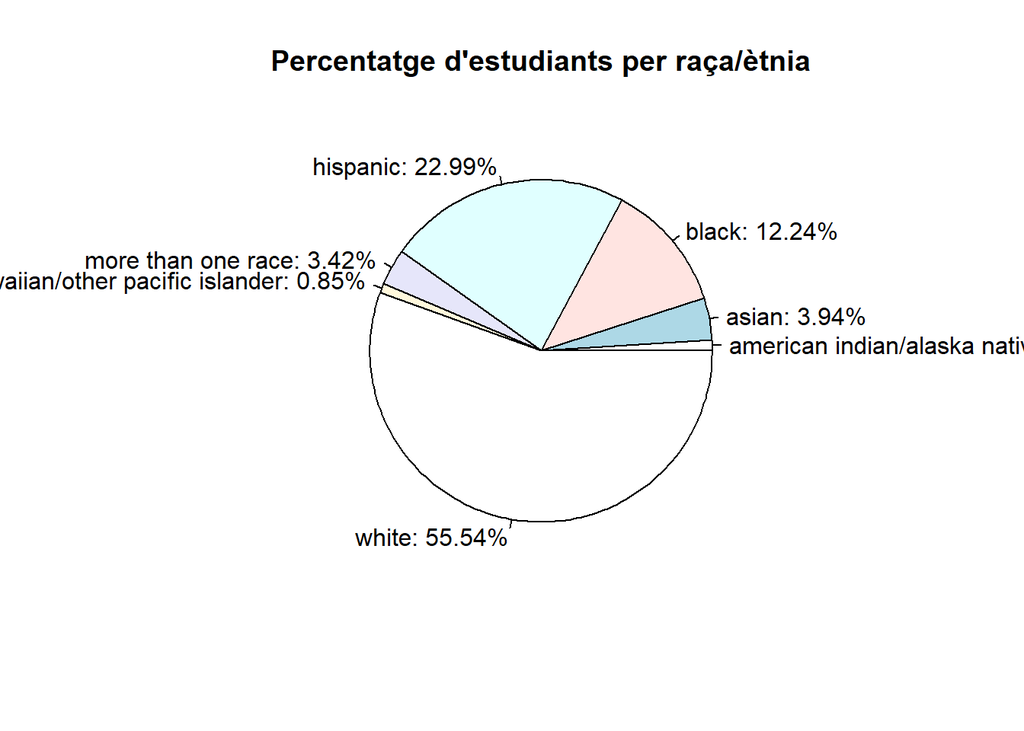

```r
# Gràfic
pie(taula_pct, main = "Percentatge d'estudiants per raça/ètnia", labels = paste(names(taula_pct), ": ", round(taula_pct, 2), "%", sep=""))
```

Al joc de dades hi ha grups més representatius que d’altres, sent *white* la categoria predominant, amb més de la meitat dels estudiants, seguida per *hispanic* i *black*. Això pot ser a causa de la demografia de la població.

# 3. Normalització i descripció de variables binàries

El conjunt de dades conté un nombre elevat de variables binàries. Reviseu els seus valors i en cas d’errors o inconsistències, corregiu els valors a partir dels criteris indicats. A continuació, resumiu en una taula la proporció d’estudiants per als valors positius (1) i els valors negatius (0) d’aquestes variables. Interpreteu breument.

**Requisits:**

- La taula ha de contenir una variable a cada fila i quatre columnes: nombre d’estudiants amb valor 0 a la variable, nombre d’estudiants amb valor 1, proporció d’estudiants amb valor 0 i proporció d’estudiants amb valor 1.
- Es recomana generar la taula de forma automàtica, sense haver de fer el càlcul manualment per a cada variable. Podeu fer servir funcions de la família *apply* per automatitzar aquest càlcul.

Primer modificarem els valors de *read30MinADay* per a que tingui valos 0 i 1. A continuació guardarem a *taula_bin* les variables amb les que volem treballar.

```r
# Conversió 'read30MinsADay':
dades$read30MinsADay <- ifelse(dades$read30MinsADay == "T", 1, ifelse(dades$read30MinsADay == "F", 0, NA))

# Selecció de les variables:
variables_bin <- c('male', 'preschool', 'expectBachelors', 'motherHS', 'motherBachelors',
                            'motherWork', 'fatherHS', 'fatherBachelors', 'fatherWork', 'selfBornUS',
                            'motherBornUS', 'fatherBornUS', 'englishAtHome', 'computerForSchoolwork',
                            'schoolHasLibrary', 'publicSchool', 'urban',
                            'read30MinsADay')

taula_bin <- dades[, variables_bin]

# Funció per calcular nombre i proporció de valors:
calcular_proporcio <- function(variable) {
  num_0 <- sum(variable == 0, na.rm = TRUE)
  num_1 <- sum(variable == 1, na.rm = TRUE)
  total <- length(na.omit(variable))
  prop_0 <- num_0 / total
  prop_1 <- num_1 / total
  c(num_0 = num_0, num_1 = num_1, prop_0 = prop_0, prop_1 = prop_1)
}

# Creació de la taula resum i transformació a dataframe:
taula_resum <- sapply(dades[variables_bin], calcular_proporcio)
df_resum <- as.data.frame(t(taula_resum))
rownames(df_resum) <- variables_bin

# Mostrar:
print(df_resum)
```

```
##                       num_0 num_1     prop_0    prop_1
## male                   1791  1872 0.48894349 0.5110565
## preschool              1000  2607 0.27723870 0.7227613
## expectBachelors         771  2830 0.21410719 0.7858928
## motherHS                428  3138 0.12002243 0.8799776
## motherBachelors        2129  1137 0.65186773 0.3481323
## motherWork              948  2622 0.26554622 0.7344538
## fatherHS                481  2937 0.14072557 0.8592744
## fatherBachelors        2067  1027 0.66806723 0.3319328
## fatherWork              504  2926 0.14693878 0.8530612
## selfBornUS              247  3347 0.06872565 0.9312743
## motherBornUS            817  2775 0.22744989 0.7725501
## fatherBornUS            828  2722 0.23323944 0.7667606
## englishAtHome           461  3131 0.12834076 0.8716592
## computerForSchoolwork   362  3236 0.10061145 0.8993885
## schoolHasLibrary        114  3406 0.03238636 0.9676136
## publicSchool            242  3421 0.06606607 0.9339339
## urban                  2253  1410 0.61506962 0.3849304
## read30MinsADay         2571  1047 0.71061360 0.2893864
```

*(Nota: Per poder fer els calculs i no alterar els valors NA, aquests han sigut eliminats de la taula, però no del fitxer)*

# 4. Normalització de variables quantitatives

## 4.1 Variable readingScore

Reviseu els valors de la variable readingScore i verifiqueu que estiguin dins dels marges esperats. Si hi ha algun valor erroni o molt extrem, substituir per NA. Mostreu un gràfic de tipus boxplot per visualitzar la distribució d’aquesta variable. Interpreteu el resultat.

En l’apartat 1.2 hem vist que la variable readingScore era de tipus caràcter quan ha de ser de tipus numèric, així que primer en farem la correcció i l’estudi.

```r
# Conversió a valors numèrics:
dades$readingScore <- as.numeric(dades$readingScore)
# Resum de la variable:
resum_readingScore <- summary(dades$readingScore)
iqr_readingScore <- IQR(dades$readingScore, na.rm = TRUE)

# Mostrar resultats:
print(resum_readingScore)
```

```
##    Min. 1st Qu.  Median    Mean 3rd Qu.    Max.    NA's
##   168.6   431.7   499.7   497.9   566.2   746.0       3
```

```r
print(paste("Abast Interquartílic (IQR):", iqr_readingScore))
```

```
## [1] "Abast Interquartílic (IQR): 134.4325"
```

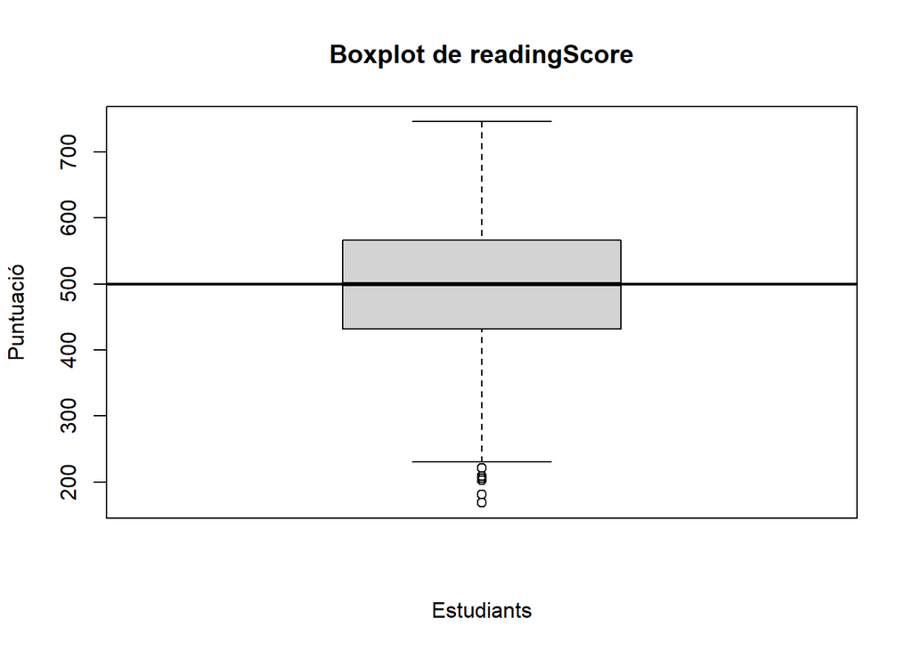

```r
# boxplot de readingScore:
boxplot(dades$readingScore,
        main = "Boxplot de readingScore",
        ylab = "Puntuació",
        xlab = "Estudiants")

# Línia horitzontal amb la mediana
abline(h = median(dades$readingScore, na.rm = TRUE), lwd = 2)
```

- **Primer Quartil:**: El 25% dels estudiants tenen una puntuació inferior a 431.7.
- **Mediana:**: El valor central de la distribució és 499.7, és a dir, la meitat dels estudiants tenen puntuacions per sota d’aquest valor i l’altre meitat per sobre. Notar que es tracta pràcticament de la meitat de la màxima puntuació.
- **Mitjana:** La mijtana és 497.9, un valor molt pròxim a la mediana.
- **Tercer Quartil:** El 75% dels estudiants tenen puntuacions per sota de 566.2.
- **Valors atípics:** A la part inferior hi podem veure cercles que representen valors atípics, és a dir, puntiacions de lectura que estan fora del rang definit per 1.5 vegades l’IQR des del primer quartil. Aquests valors poden ser errors en les dades o estudiants amb dificultats de lectura.

## 4.2 Variable grade

Mostreu visualment la distribució de la variable grade (curs). A continuació, reviseu si els valors de la variable grade estan dins dels marges raonables. Per a la mostra d’estudi, composta per estudiants de 15 anys, es correspondria al desè curs. Hi poden haver casos d’estudiants que estiguin en cursos més avançats o en cursos inferiors. Si hi ha un valor extrem o erroni, s’ha de substituir per NA.

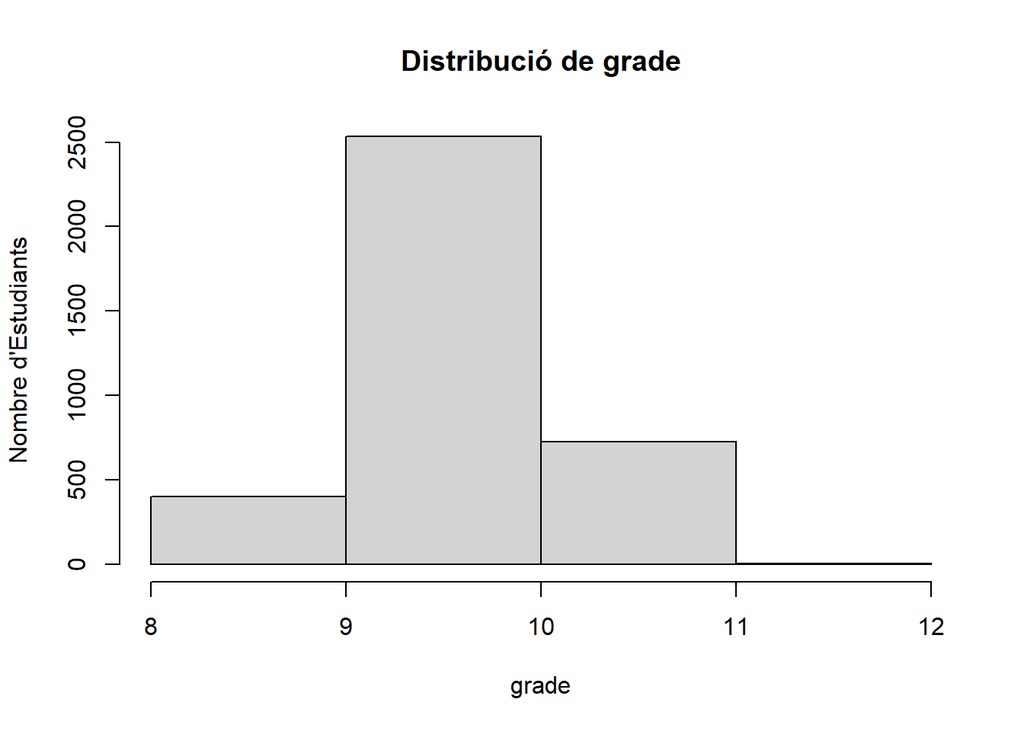

```r
hist(dades$grade, breaks = max(dades$grade) - min(dades$grade),
     main = "Distribució de grade",
     xlab = "grade",
     ylab = "Nombre d'Estudiants")
```

Podem observar que la majoria d’alumnes estan al curs que els hi pertoca, tot i això hi ha alumnes amb cursos enderrerits i avançats. Crida l’atenció que hi ha més alumnes en cursos avançats que endererits. Finalment, comentar que hi ha unes poques mostres on el curs és molt avançat. A continuació mirarem quants casos n’hi ha i decidirem com els tractarem.

```r
# Càlcul del valor màxim
max_grade <- max(dades$grade)

# Comptem el nombre de mostres amb valor màxim
count_max_grade <- sum(dades$grade == max_grade, na.rm = TRUE)

count_max_grade
```

```
## [1] 4
```

Hi ha 4 casos en els que l’alumne està dos cursos avançat a la resta dels alumnes. Aquests casos els contemplarem com extrems i els substituïrem per valors NA.

```r
dades$grade[dades$grade == max_grade] <- NA
summary(dades$grade)
```

```
##    Min. 1st Qu.  Median    Mean 3rd Qu.    Max.    NA's
##    8.00   10.00   10.00   10.09   10.00   11.00       4
```

Un cop aplicats els canvis aprofitem per veure un resum del nostre joc de dades per veure que, efectivament, s’han aplicat els canvis i el valor màxim de grade és 11.

## 4.3 Variable schoolSize

Mostreu visualment la distribució de la variable schoolSize. Si hi ha valors erronis, substituïu per NA. La imputació es farà més endavant.

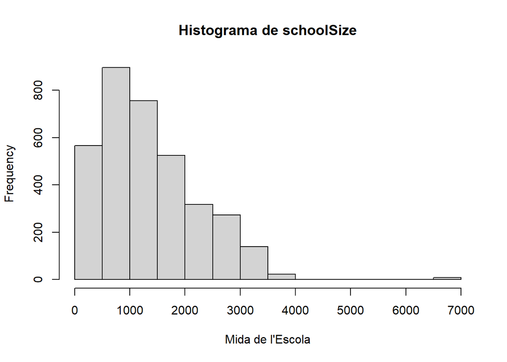

```r
hist(dades$schoolSize,
     main = "Histograma de schoolSize",
     xlab = "Mida de l'Escola")
```

Observem en el gràfic que la majoria de les escoles tenen una mida que oscil·la al voltant dels 1000 estudiants. A més, podem veure que la distribució es concentra més als rangs menors, cosa que ens indica que l’habitual són les coles més petites. També hi podem observar una cua cap a la dreta amb escoles amb major nombre d’estudiants, tot i que són menys freqüents. Finalment notar que hi ha mostres entre 6000 i 7000 alumnes, no tenim prou informació per saber si es tracta d’un error o un valor atípic però el substituïrem per un valor NA, ja que s’allunya molt de la resta de les dades. Per a fer-ho, posarem el punt de tall a les escoles amb més de 4000 alumnes.

```r
dades$schoolSize[dades$schoolSize > 4000] <- NA
summary(dades$schoolSize)
```

```
##    Min. 1st Qu.  Median    Mean 3rd Qu.    Max.    NA's
##     100     712    1212    1356    1900    3592     171
```

Al igual que amb la variable anterior, aprofitem per veure un resum i comprovar si els canvis s’han realitzat correctament.

# 5. Imputació

En aquest apartat, farem la imputació sobre els valors perduts de la variable schoolSize. Apliqueu imputació per veïns més propers, utilitzant la distància de Gower, considerant en el còmput dels veïns més propers les variables numèriques. Per realitzar aquesta imputació, es pot fer servir la funció “kNN” de la llibreria VIM amb un nombre de veïns igual a 5. Demostreu que la imputació s’ha realitzat correctament, visualitzant algunes de les dades afectades per la imputació. Finalment, analitzeu des d’un punt de vista crític el procés d’imputació realitzat.

```r
if (!require("VIM", character.only = TRUE)) {
  install.packages("VIM", dependencies = TRUE)
  library(VIM)
}
```

```
## VIM is ready to use.
```

```
## Suggestions and bug-reports can be submitted at: https://github.com/statistikat/VIM/issues
```

Un cop carrega i instal·lada (en cas que sigui necessari) la llibreria, farem la imputació. Com només treballarem amb les variables numèriques primer hem de excloure la columna **raceeth** del nostre anàlisi. A més, per a poder reproduïr els càlculs i no haver de modificar l’informe, fixarem un **seed**.

```r
dades_num <- dades[, setdiff(names(dades), "raceeth")]

set.seed(42)
dades_imputades <- kNN(dades_num, variable = "schoolSize", k = 5, metric = "gower")

summary(dades_imputades$schoolSize)
```

```
##    Min. 1st Qu.  Median    Mean 3rd Qu.    Max.
##     100     754    1212    1358    1900    3592
```

Ara és el moment de visualitzar algunes de les imputacions realitzades.

```r
# Obtenció dels index amb valors NA del df original
na_index <- which(is.na(dades$schoolSize))

comparativa <- data.frame(
  Original = dades$schoolSize[na_index],
  Imputades = dades_imputades$schoolSize[na_index]
)

head(comparativa, 5)
```

```
##   Original Imputades
## 1       NA      1276
## 2       NA      1680
## 3       NA      3000
## 4       NA      1196
## 5       NA      1734
```

El haver fet servir la distància de Gower per a la imputació ens ha permès fer servir les variables categòriques que amb altre tipus de distància no tindrien sentit. El cost computacional ha sigut petit ja que només hem considerat *k=5*, si es volgués ser més precís caldria augmentar el valor de *k* tot i que impliqui un cost computacional més elevat.

# 6. Mesures característiques de les variables numèriques

Calculeu les mesures de tendència central i dispersió, tant robustes com no robustes, de les variables quantitatives numèriques grade, minutesPerWeekEnglish, studentsInEnglish, schoolSize i readingScore. Es presentaran dues taules, una amb les mesures de tendència central i una altra amb les mesures de dispersió. A la taula de tendència central, mostreu la mitjana, mediana, i mitjana retallada al 5%. A la taula de dispersió, mostreu la desviació estàndard, el rang interquartílic i la desviació absoluta respecte de la mitjana.

**Requisits:**

- Igual que anteriorment, realitzeu aquest càlcul sense haver de calcular la informació de cada variable per separat. Feu servir les funcions de la família *apply*.
- Per practicar el desenvolupament de funcions en R, us demanem que implementeu la funció que calcula la desviació estàndard i feu servir aquesta funció en lloc de la funció *sd* que proporciona R.

**Nota:**

- Com que no hem realitzat imputació per a totes les variables numèriques, si existeixen NAs en algunes variables, podeu ignorar aquests valors per fer aquests càlculs. Podeu fer servir el paràmetre *na.rm=TRUE*.

Primer crearem la funció personalitzada per a la **Desviació Estàndard**, que es defineix com

$sd = \sqrt{\frac{1}{n-1}\sum(x_i-\bar{x})^2}$

```r
# Funció custom per calcular la desviació estàndard
custom_sd <- function(x, na.rm = FALSE) {
  if (na.rm) {
    x <- x[!is.na(x)]
  }
  n <- length(x)
  mean_x <- mean(x)
  sqrt(sum((x - mean_x)^2) / (n - 1))
}
```

A continuació calcularem les mesures de tendència central i dispresió. Farem servir *trim=0.05* per retallar al 5%.

```r
variables <- c("grade", "minutesPerWeekEnglish", "studentsInEnglish", "schoolSize", "readingScore")

tendencia_central <- sapply(dades_imputades[variables], function(x) {
  c(Mitjana = mean(x, na.rm = TRUE),
    Mediana = median(x, na.rm = TRUE),
    `Mitjana Retallada` = mean(x, trim = 0.05, na.rm = TRUE))
})

dispersio <- sapply(dades_imputades[variables], function(x) {
  c(`Desviació Estàndard` = custom_sd(x, na.rm = TRUE),
    `Rang Interquartílic` = IQR(x, na.rm = TRUE),
    `Desviació Absoluta` = mad(x, na.rm = TRUE))
})

print("Taula de Tendència Central:")
```

```
## [1] "Taula de Tendència Central:"
```

```r
print(tendencia_central)
```

```
##                      grade minutesPerWeekEnglish studentsInEnglish schoolSize
## Mitjana           10.08773              266.2082          24.49941   1357.766
## Mediana           10.00000              250.0000          25.00000   1212.000
## Mitjana Retallada 10.09863              255.7240          24.36727   1319.189
##                   readingScore
## Mitjana               497.8812
## Mediana               499.6600
## Mitjana Retallada     498.7160
```

```r
print("Taula de Dispersió:")
```

```
## [1] "Taula de Dispersió:"
```

```r
print(dispersio)
```

```
##                         grade minutesPerWeekEnglish studentsInEnglish
## Desviació Estàndard 0.5510661              148.4035          7.184348
## Rang Interquartílic 0.0000000               75.0000         10.000000
## Desviació Absoluta  0.0000000               51.8910          7.413000
##                     schoolSize readingScore
## Desviació Estàndard   819.4396     95.51096
## Rang Interquartílic  1146.0000    134.43250
## Desviació Absoluta    853.9776     99.09698
```

# 7. Arxiu final

Un cop realitzat el preprocessament sobre el fitxer, desar el resultat de les dades en un fitxer csv anomenat pisa_clean.csv.

Finalment només hem de transformar el nostre data frame *dades_imputades* a un fitxer csv.

```r
write.csv(dades_imputades, file = "pisa_clean.csv", row.names = FALSE)
```